# PCFG: Strawdog State Space Model

This code can be run with R and cmdstan (to compile and run the Stan code). The R working directory is assumed to be that where this README file resides(e.g., if you use RStudio, put your *.RProj file in that same top directory, or use the `setwd()` command in R, etc.). The R control script is “./R/pcfg_lognorm.R”.

The state space model code is in “./STAN/pcfg_lognorm.stan”. Note that code also stores the point-wise log-likelihood, which would allow other models (e.g., with auto-correlated process error) to be compared statistically, in terms of predictive accuracy, through leave-one-out (LOO) cross-validation.

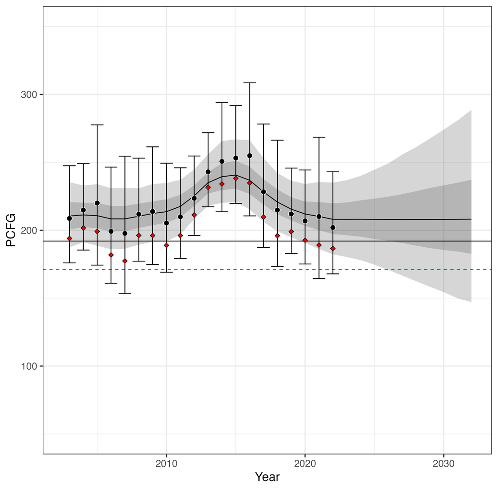

## Update: 10/19/2024

The following depicts projections from various updated model variants. All now include harvest with abundance projected out three years (2025), though for sake of simplicity and model transparency harvest has been set to 0.

### Original model with harvest

Original model with harvest (set to 0) and projected three years out for comparison.

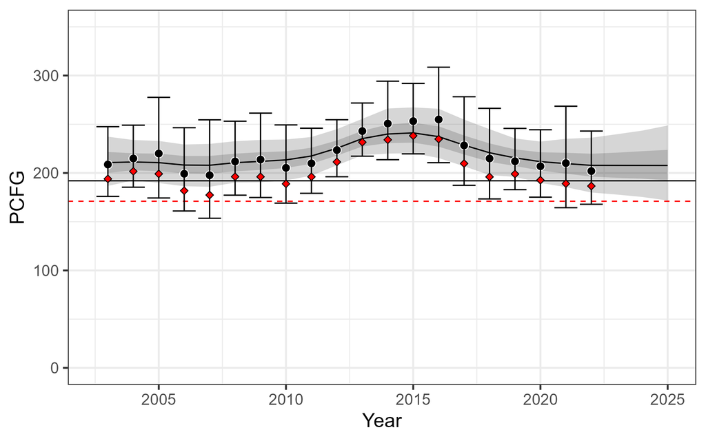

### Original model with logLambda and harvest

Previous model assumed lambda was normal, but it is not. This version (and only this model currently) uses logLambda (r) instead.

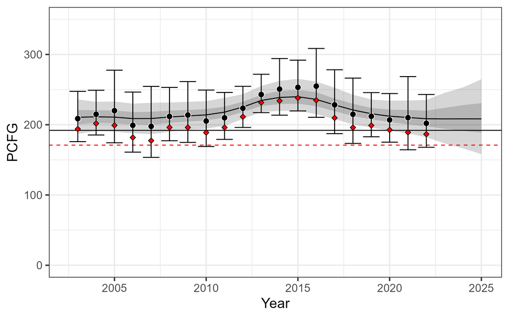

### AR1 model version 1

Uses lambda as in the original model, but now models consecutive lambdas as a function of the previous year’s lambda.

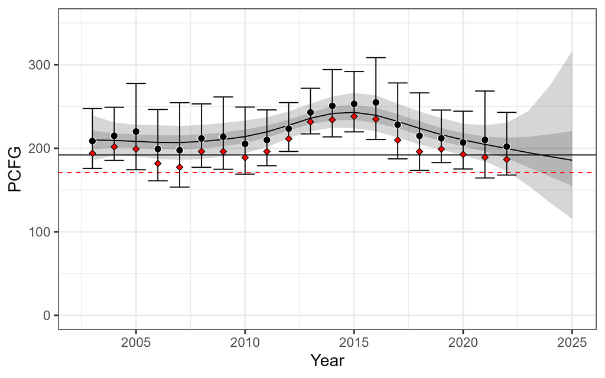

### AR1 model version 2

Uses lambda as in the original model. A more traditional, regression based AR1 model. Not ideal, but figured it was worth seeing the differences.

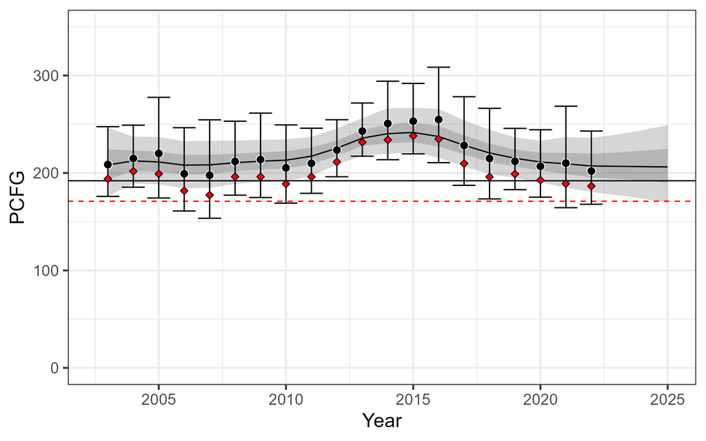

### Lambda as a function of calf numbers

Models lambda as a function of calf numbers (no time lag). Present figure is depicted an assumed 2 calves per year for three years without abundance estimates.

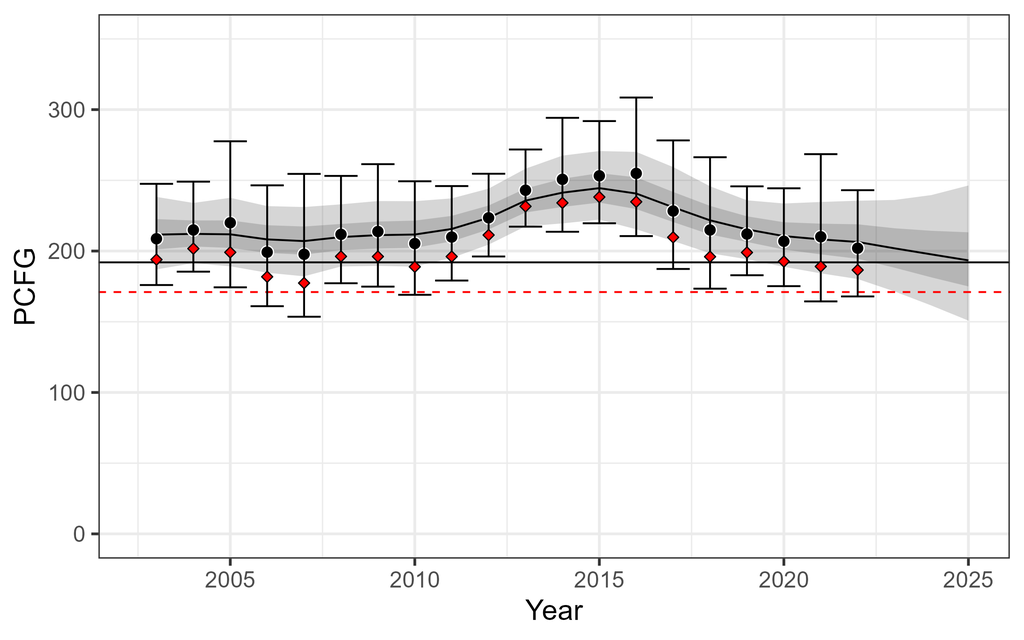